# FRIS-IWMS Manuscript Visualizations, by Figure #

Britta Schumacher

Last updated: 20 July, 2021

### Set up

Load relevant packages & common data

```r
library(ggplot2)
library(sp)
library(tidyverse)
library(tmap)
library(RColorBrewer)
library(rgeos)
library(spdplyr)
library(viridis)
library(rgdal)
library(rgeos)
library(ggpubr)

ctys <- readRDS("./data/county.RDS")
w_ctys <- readRDS("./data/western_ctys.RDS")
state <- readRDS("./data/states.RDS")
```

### Figure 1.

Percent of a county’s agricultural lands irrigated in 2018. Data: USDA NASS Survey.

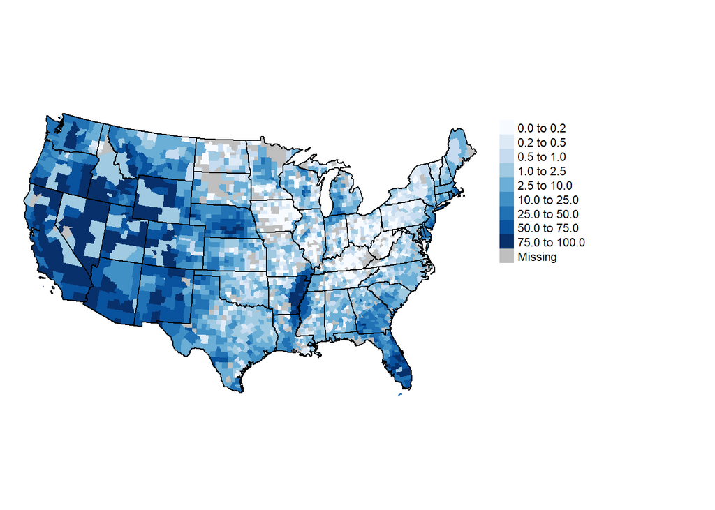

```r
# build irrigation in 2018
irr <- readRDS("./data/full_merged_irrigation.RDS")
i18 <- irr %>% dplyr::select(GEOID,YEAR,AG_ACRES, IRR_ACRES, PERC_IRR, SOURCE) %>% filter(YEAR == 2018) %>%  filter(SOURCE == "NASS")

i18 <- i18[complete.cases(i18), ]
i18_sp <- merge(ctys, i18, by = "GEOID")

map <- tm_shape(i18_sp) +
  tm_polygons(col = "PERC_IRR", breaks = c(0.0,0.2,0.50,1.0,2.50,10.0,25.0,50.0,75.0,100.0), palette = "Blues", border.col = "transparent", title = "") +
  tm_legend(outside = TRUE) +
  tm_layout(frame = FALSE) +
    tm_shape(state) +
  tm_borders(col = "black")

map
```

```r
tmap_save(map, file = paste0('./viz/Manuscript-Figures/Figure1.jpeg'), width = 220, height = 120, units = "mm", dpi = 400)
```

### Figure 2.

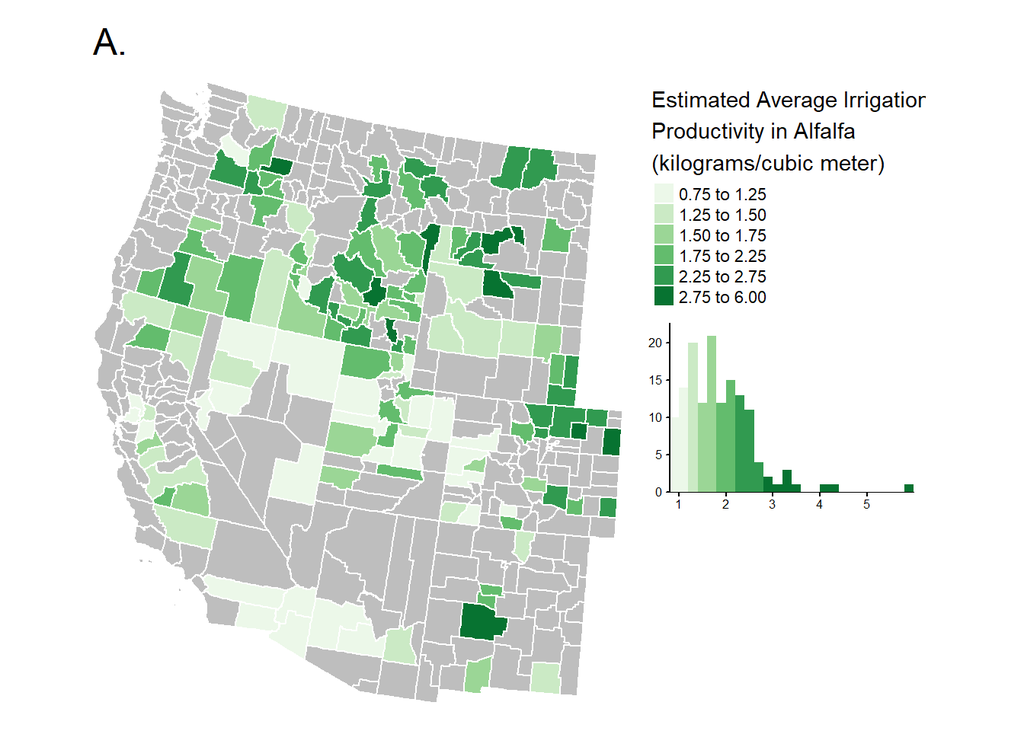

```r
# Build spatial across crops using the _indyrs datasets (summarizes across individual years)
fris_sp_indyrs <- readRDS("./data/sumstat_indyrs.RDS")
cty_names <- readRDS("./data/cty_names.RDS")

sumstat_indyrs_df <- merge(cty_names, fris_sp_indyrs)
x <- sumstat_indyrs_df %>% filter(YEAR == 2018)

sp_indyrs_fris <- sp::merge(w_ctys, fris_sp_indyrs, by = "GEOID", duplicateGeoms = TRUE, all = TRUE)

# A) alfalfa IP
alfalfa <- sp_indyrs_fris %>%
    filter(CROP == "ALFALFA") %>%
    filter(YEAR == 2018)

alfalfa_ip_map <- tm_shape(w_ctys) + tm_polygons(col="grey", border.col = "white") +
  tm_shape(alfalfa) +
      tm_layout(main.title = "A.", main.title.position = c("left"), frame= FALSE, legend.hist.size = 0.5) +
    tm_polygons(col="EST_IP_KG_M", breaks = c(0.75,1.25,1.5,1.75,2.25,2.75,6.0), palette = "Greens", border.col = "white",
              legend.hist = TRUE, title = "Estimated Average Irrigation\nProductivity in Alfalfa\n(kilograms/cubic meter)") +
    tm_legend(outside = TRUE, hist.width = 1.5)

alfalfa_ip_map
```

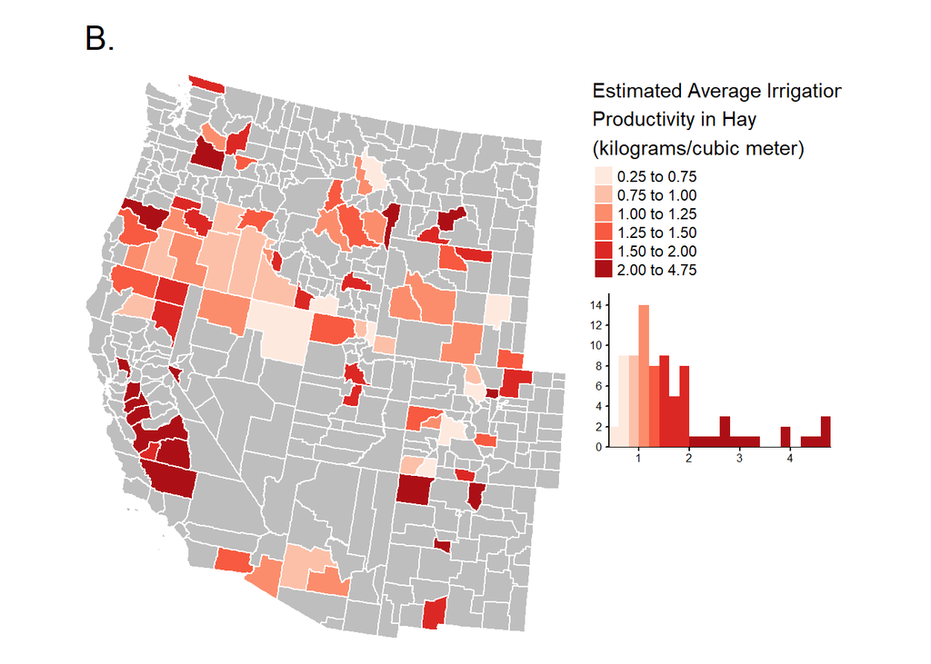

```r
# A) hay IP
hay <- sp_indyrs_fris %>%
    filter(CROP == "OTHER_HAY") %>%
    filter(YEAR == 2018)

hay_ip_map <- tm_shape(w_ctys) + tm_polygons(col="grey", border.col = "white") +
  tm_shape(hay) +
    tm_polygons(col="EST_IP_KG_M", breaks = c(0.25,0.75,1,1.25,1.5,2,4.75), palette = "Reds", border.col = "white",
              legend.hist = TRUE, title = "Estimated Average Irrigation\nProductivity in Hay\n(kilograms/cubic meter)") +
    tm_legend(outside = TRUE, hist.width = 1.5) +
    tm_layout(main.title = "B.", main.title.position = c("left"), frame= FALSE, legend.hist.size = 0.5)

hay_ip_map
```

```r
figure2 <- tmap_arrange(alfalfa_ip_map, hay_ip_map)
tmap_save(figure2, "./viz/Manuscript-Figures/Figure2.jpeg", width = 300, height = 120, units = "mm", dpi = 400)
```

### Figure 3.

Average Estimated Yield in A) Alfalfa and B) Hay in 2018.

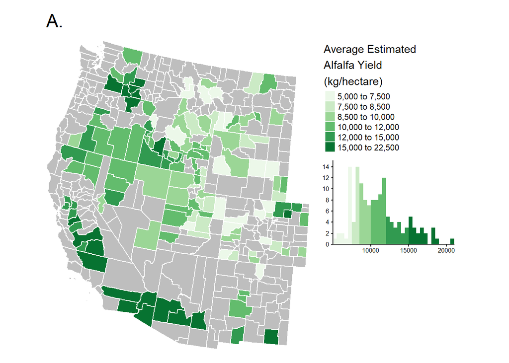

```r
# A) alfalfa yield
alfalfa <- sp_indyrs_fris %>%
    filter(CROP == "ALFALFA") %>%
    filter(YEAR == 2018)

alfalfa_yield_map <- tm_shape(w_ctys) + tm_polygons(col="grey", border.col = "white") +
  tm_shape(alfalfa) +
      tm_layout(main.title = "A.", main.title.position = c("left"), frame= FALSE, legend.hist.size = 0.5) +
    tm_polygons(col="EST_AVE_YIELD_KG", breaks = c(5000,7500,8500,10000,12000,15000,22500), palette = "Greens", border.col = "white",
              legend.hist = TRUE, title = "Average Estimated\nAlfalfa Yield\n(kg/hectare)") +
    tm_legend(outside = TRUE, hist.width = 1.5)

alfalfa_yield_map
```

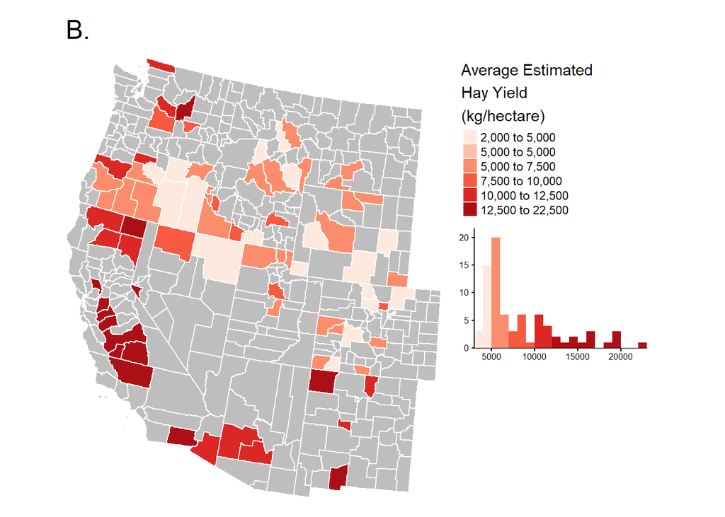

```r
# A) hay yield
hay <- sp_indyrs_fris %>%
    filter(CROP == "OTHER_HAY") %>%
    filter(YEAR == 2018)

hay_yield_map <- tm_shape(w_ctys) + tm_polygons(col="grey", border.col = "white") +
  tm_shape(hay) +
    tm_polygons(col="EST_AVE_YIELD_KG", breaks = c(2000,5000,5000,7500,10000,12500,22500), palette = "Reds", border.col = "white",
              legend.hist = TRUE, title = "Average Estimated\nHay Yield\n(kg/hectare)") +
    tm_legend(outside = TRUE, hist.width = 1.5) +
    tm_layout(main.title = "B.", main.title.position = c("left"), frame= FALSE, legend.hist.size = 0.5)

hay_yield_map
```

```r
figure3 <- tmap_arrange(alfalfa_yield_map, hay_yield_map)
tmap_save(figure3, "./viz/Manuscript-Figures/Figure3.jpeg", width = 300, height = 120, units = "mm", dpi = 400)
```

### Figure 4.

Estimated Average Irrigation Productivity Across Crops and Years.

```r
# see analysis_nomaps_notrends_APPROVED.html for code! Cannot reproduce because this viz was built with grower-level data held securely by the USDA.
```

### Figure 5.

Change in Water Application Rates in Alfalfa Between 2013 & 2018.

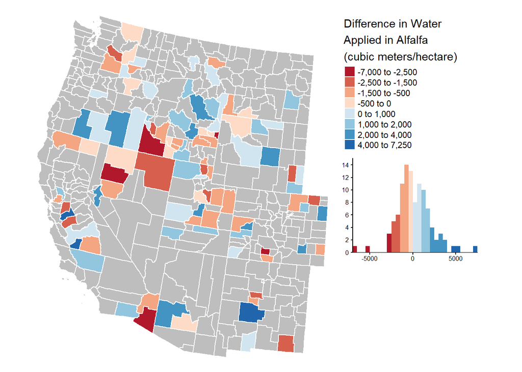

```r
# n >= 10 observations/cty-yr
x <- fris_sp_indyrs %>%
  filter(YEAR == 2018) %>%
  select(!YEAR)

x2 <- fris_sp_indyrs %>%
  filter(YEAR == 2013) %>%
  select(!YEAR)

y <- merge(x, x2, by = c("GEOID", "CROP")) # to find differences, use code within function, below

  x <- y %>%
    filter(CROP == "ALFALFA") %>%
    mutate(yield_diff_LBS = (EST_AVE_YIELD_LBS.y - EST_AVE_YIELD_LBS.x), # yield (pounds/acre)
           yield_diff_KG = (EST_AVE_YIELD_KG.y - EST_AVE_YIELD_KG.x), # yield (kg/hectare)
           wa_diff_AF = (EST_AVE_WU_AF.y - EST_AVE_WU_AF.x),    # water applied (acre feet/acre)
           wa_diff_M = (EST_AVE_WU_M.y - EST_AVE_WU_M.x), # water applied (cubic meter/hectare)
           ip_diff_LBSAF = (EST_IP_LBS_AF.y - EST_IP_LBS_AF.x), # irrigation productivity (pounds / AF)
           ip_diff_KGM = (EST_IP_KG_M.y - EST_IP_KG_M.x)) # irrigation productivity (kg / cubic meter)

# build spatial
sp_diff <- sp::merge(ctys, y, by = "GEOID", duplicateGeoms = TRUE, all = TRUE)

alfalfa_wu <- sp_diff %>%
    filter(CROP == "ALFALFA") %>%
    mutate(wa_diff_M = (EST_AVE_WU_M.y - EST_AVE_WU_M.x)) # water applied (cubic meter/hectare)

alfalfa_wu_diff <- tm_shape(w_ctys) + tm_polygons(col="grey", border.col = "white") +
  tm_shape(alfalfa_wu) +
    tm_polygons(col= "wa_diff_M", breaks = c(-7000,-2500,-1500,-500,0,1000,2000,4000, 7250), palette = c("#B2182B", "#D6604D", "#F4A582", "#FDDBC7", "#D1E5F0", "#92C5DE", "#4393C3", "#2166AC"), border.col = "white", legend.hist = TRUE, title = "Difference in Water\nApplied in Alfalfa\n(cubic meters/hectare)") +
    tm_legend(outside = TRUE, hist.width = 1.5) +
    tm_layout(frame= FALSE, legend.hist.size = 0.5)

alfalfa_wu_diff
```

```r
tmap_save(alfalfa_wu_diff, './viz/Manuscript-Figures/Figure5.jpeg', width = 150, height = 150, units = "mm", dpi = 400)
```

### Figure 6.

Map of primary irrigation information source reported in 2018; number of counties citing each source in parentheses (e.g., in 2018, 82 counties cited neighbors as their primary irrigation source). Note, primary use across correlates was not self-identified by growers but built by the method identified in section 2.3 (code, github.com/###/FRIS-IWMS/clean-NORC-approved-data.Rmd).

```r
w <- readRDS("./data/info-prop-indyrs.RDS")

w <- w %>% filter(YEAR == 2018) %>% select(!c("total")) %>% gather(category, proportion, 5:12) %>%   mutate(
    category = case_when(
      category == "K1040" ~ "K1040 - Extension or university",
      category == "K1041" ~ "K1041 - Private consultants",
      category == "K1042" ~ "K1042 - Equipment dealers",
      category == "K1043" ~ "K1043 - Irrigation district",
      category == "K1044" ~ "K1044 - Government",
      category == "K1045" ~ "K1045 - Press",
      category == "K1046" ~ "K1046 - Neighbors",
      category == "K1047" ~ "K1047 - Internet"
    )
  )

# Select most important source by proportion for each county
find_18 <- w %>% group_by(GEOID) %>% filter(proportion == max(proportion))

# %>% mutate(place=1) %>% group_by(category) %>%  summarise(count = sum(place))
find_summary18 <- find_18 %>%
  group_by(category) %>%
  summarise(n = n())
find_summary18
```

```
## # A tibble: 8 x 2
##   category                            n
##   <chr>                           <int>
## 1 K1040 - Extension or university    46
## 2 K1041 - Private consultants        32
## 3 K1042 - Equipment dealers          23
## 4 K1043 - Irrigation district        21
## 5 K1044 - Government                  9
## 6 K1045 - Press                       1
## 7 K1046 - Neighbors                  82
## 8 K1047 - Internet                    4
```

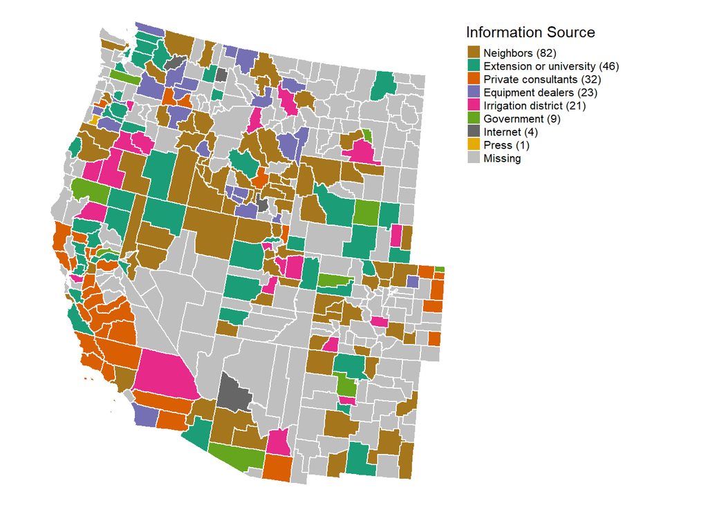

```r
# rename variables for nicer viz
find_18 <- find_18 %>%
  mutate(
    category = case_when(
      category == "K1040 - Extension or university" ~ "Extension or university (46)",
      category == "K1041 - Private consultants" ~ "Private consultants (32)",
      category == "K1042 - Equipment dealers" ~ "Equipment dealers (23)",
      category == "K1043 - Irrigation district" ~ "Irrigation district (21)",
      category == "K1044 - Government" ~ "Government (9)",
      category == "K1045 - Press" ~ "Press (1)",
      category == "K1046 - Neighbors" ~ "Neighbors (82)",
      category == "K1047 - Internet" ~ "Internet (4)"
    )
  )

find_18$category <- as.factor(find_18$category)
find_18$category <- ordered(find_18$category, levels = c("Neighbors (82)", "Extension or university (46)", "Private consultants (32)", "Equipment dealers (23)", "Irrigation district (21)","Government (9)","Internet (4)","Press (1)"))

colnames(find_18)[5] <- "Information Source"

info_sp18 <- sp::merge(w_ctys, find_18, by = "GEOID", duplicateGeoms = TRUE, all = TRUE)

info_map18 <- tm_shape(w_ctys) + tm_polygons(col="grey", border.col = "white") +
  tm_shape(info_sp18) +
    tm_polygons("Information Source", palette = c("#A6761D","#1B9E77","#D95F02","#7570B3", "#E7298A", "#66A61E","#666666","#E6AB02"), border.col = "white")  +
    tm_legend(outside = TRUE) +
    tm_layout(frame= FALSE,
              legend.text.size = 0.65)

info_map18
```

```r
tmap_save(info_map18, "./viz/Manuscript-Figures/Figure6.png", width = 150, height = 150, units = "mm", dpi = 400)
```

### Figure 7.

Map of primary irrigation scheduling method reported in 2018; number of counties citing each method in parentheses. Note, no county reported use of plant moisture sensors, daily crop-water evapo-transpiration reports, or computer simulation models as their primary scheduling method in 2018.

```r
w <- readRDS("./data/sched-prop-indyrs.RDS")

w <- w %>% filter(YEAR == 2018) %>% select(!c("total")) %>% gather(category, proportion, 5:14) %>%
  mutate(
    category = case_when(
      category == "K1020" ~ "K1020 - Condition of crop",
      category == "K1021" ~ "K1021 - Feel of the soil",
      category == "K1022" ~ "K1022 - Soil moisture sensor",
      category == "K1023" ~ "K1023 - Plant moisture sensor",
      category == "K1024" ~ "K1024 - Scheduling service",
      category == "K1025" ~ "K1025 - Daily crop-water ET",
      category == "K1026" ~ "K1026 - Water delivered in turn",
      category == "K1027" ~ "K1027 - Personal calendar",
      category == "K1028" ~ "K1028 - Computer simulation models",
      category == "K1029" ~ "K1029 - When neighbors watered"
    )
  )

# Select most important source by proportion for each county
find_18 <- w %>% group_by(GEOID) %>% filter(proportion == max(proportion))

# how many counties are in each category on the maps?
find_summary18 <- find_18 %>%
  group_by(category) %>%
  summarise(n = n())
find_summary18
```

```
## # A tibble: 7 x 2
##   category                            n
##   <chr>                           <int>
## 1 K1020 - Condition of crop         253
## 2 K1021 - Feel of the soil            7
## 3 K1022 - Soil moisture sensor        1
## 4 K1024 - Scheduling service          4
## 5 K1026 - Water delivered in turn    31
## 6 K1027 - Personal calendar           2
## 7 K1029 - When neighbors watered      1
```

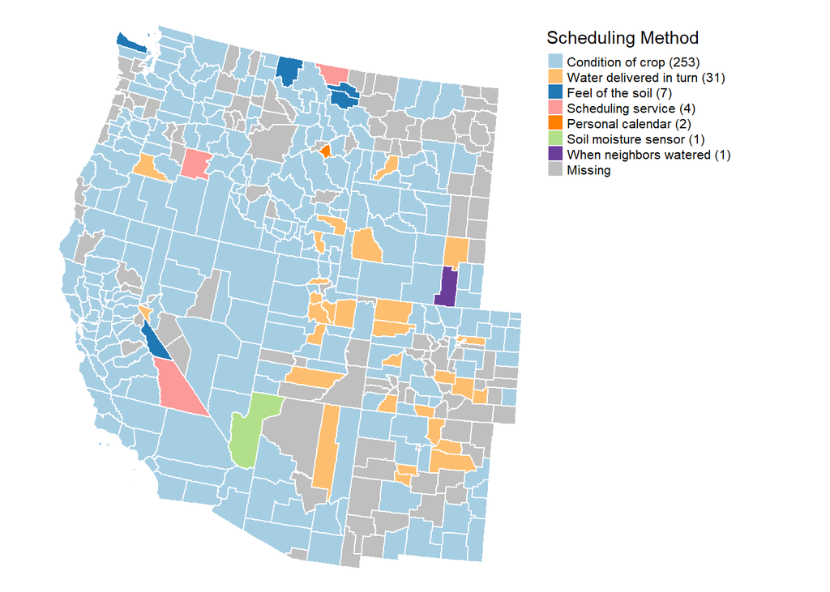

```r
# rename variables for nicer viz
find_18 <- find_18 %>%
  mutate(
    category = case_when(
      category == "K1020 - Condition of crop" ~ "Condition of crop (253)",
      category == "K1021 - Feel of the soil" ~ "Feel of the soil (7)",
      category == "K1022 - Soil moisture sensor" ~ "Soil moisture sensor (1)",
      category == "K1023 - Plant moisture sensor" ~ "Plant moisture sensor (0)",
      category == "K1024 - Scheduling service" ~ "Scheduling service (4)",
      category == "K1025 - Daily crop-water ET" ~ "Daily crop-water ET (0)",
      category == "K1026 - Water delivered in turn" ~ "Water delivered in turn (31)",
      category == "K1027 - Personal calendar" ~ "Personal calendar (2)",
      category == "K1028 - Computer simulation models" ~ "Computer simulation models (0)",
      category == "K1029 - When neighbors watered" ~ "When neighbors watered (1)"
    )
  )

find_18$category <- ordered(find_18$category, levels = c("Condition of crop (253)", "Water delivered in turn (31)", "Feel of the soil (7)", "Scheduling service (4)", "Personal calendar (2)","Soil moisture sensor (1)","When neighbors watered (1)"))

# rename columns for visualizations
colnames(find_18)[5] <- "Scheduling Method"

sched18_sp <- sp::merge(w_ctys, find_18, by = "GEOID", duplicateGeoms = TRUE, all = TRUE)

# build maps
sched18_map <- tm_shape(w_ctys) + tm_polygons(col="grey", border.col = "white") +
  tm_shape(sched18_sp) +
    tm_polygons("Scheduling Method", palette = c("#A6CEE3", "#FDBF6F", "#1F78B4", "#FB9A99", "#FF7F00", "#B2DF8A", "#6A3D9A"), border.col = "white")  +
    tm_legend(outside = TRUE) +
    tm_layout(frame= FALSE,
              legend.text.size = 0.65)

sched18_map
```

```r
tmap_save(sched18_map, "./viz/Manuscript-Figures/Figure7.png", width = 150, height = 150, units = "mm", dpi = 400)
```

### Figure 8.

Map of primary barriers to implementing irrigation improvements reported in 2018; number of counties citing each source in parentheses.

```r
w <- readRDS("./data/barrier-prop-indyrs.RDS")

w <- w %>% filter(YEAR == 2018) %>% select(!c("total")) %>% gather(category, proportion, 5:13) %>%
  mutate(
    category = case_when(
      category == "K1070" ~ "K1070 - Low priority",
      category == "K1071" ~ "K1071 - Reduced yield or quality",
      category == "K1072" ~ "K1072 - Physical conditions",
      category == "K1073" ~ "K1073 - Cost outweighs benefits",
      category == "K1074" ~ "K1074 - Cannot finance",
      category == "K1075" ~ "K1075 - No landlord cost-share",
      category == "K1076" ~ "K1076 - Water uncertainty",
      category == "K1077" ~ "K1077 - Not farming long-term",
      category == "K1078" ~ "K1078 - Time and cost increase"
    )
  )

# Select most important source by proportion for each county
find_18 <- w %>% group_by(GEOID) %>% filter(proportion == max(proportion))

# Number of counties in each category
find18_summary <- find_18 %>%
  group_by(category) %>%
  summarise(n = n())
find18_summary
```

```
## # A tibble: 9 x 2
##   category                             n
##   <chr>                            <int>
## 1 K1070 - Low priority                69
## 2 K1071 - Reduced yield or quality     7
## 3 K1072 - Physical conditions         11
## 4 K1073 - Cost outweighs benefits     23
## 5 K1074 - Cannot finance              68
## 6 K1075 - No landlord cost-share       1
## 7 K1076 - Water uncertainty           35
## 8 K1077 - Not farming long-term        7
## 9 K1078 - Time and cost increase       3
```

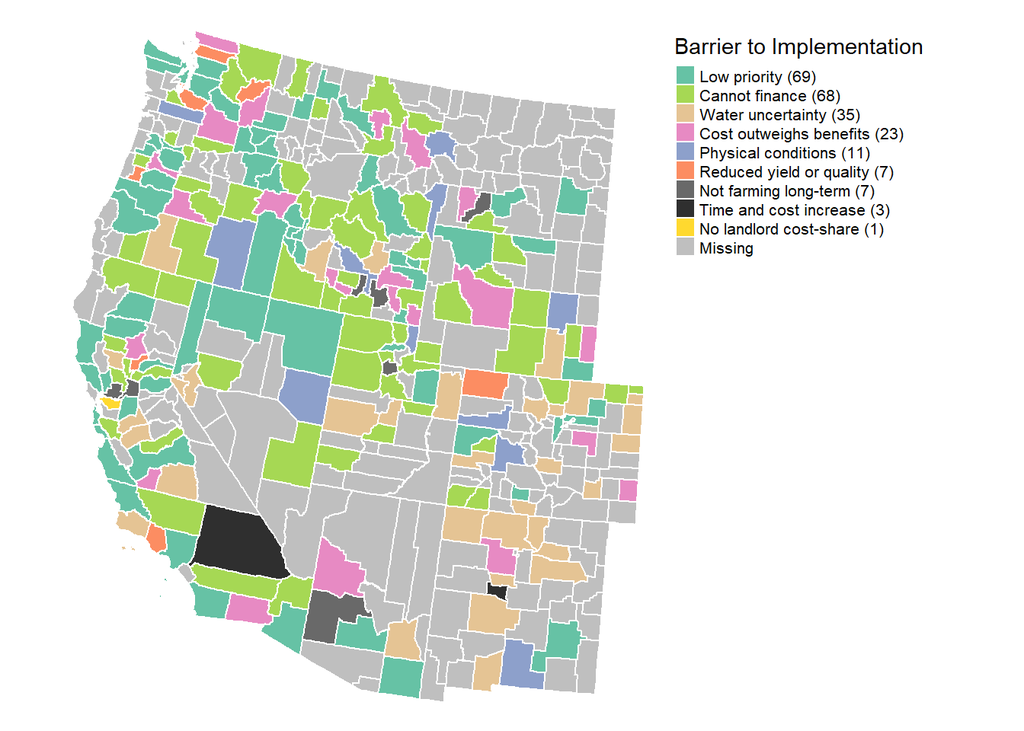

```r
# rename variables for nicer viz
find_18 <- find_18 %>%
  mutate(
    category = case_when(
      category == "K1070 - Low priority" ~ "Low priority (69)",
      category == "K1071 - Reduced yield or quality" ~ "Reduced yield or quality (7)",
      category == "K1072 - Physical conditions" ~ "Physical conditions (11)",
      category == "K1073 - Cost outweighs benefits" ~ "Cost outweighs benefits (23)",
      category == "K1074 - Cannot finance" ~ "Cannot finance (68)",
      category == "K1075 - No landlord cost-share" ~ "No landlord cost-share (1)",
      category == "K1076 - Water uncertainty" ~ "Water uncertainty (35)",
      category == "K1077 - Not farming long-term" ~ "Not farming long-term (7)",
      category == "K1078 - Time and cost increase" ~ "Time and cost increase (3)"
    )
  )

find_18$category <- ordered(find_18$category, levels = c("Low priority (69)", "Cannot finance (68)", "Water uncertainty (35)", "Cost outweighs benefits (23)", "Physical conditions (11)","Reduced yield or quality (7)","Not farming long-term (7)","Time and cost increase (3)","No landlord cost-share (1)"))

# Change colnames for visuzaliation
colnames(find_18)[5] <- "Barrier to Implementation"

barrier18_sp <- sp::merge(w_ctys, find_18, by = "GEOID", duplicateGeoms = TRUE, all = TRUE)

# Make a map for just 2018
barrier18_map <- tm_shape(w_ctys) + tm_polygons(col="grey", border.col = "white") +
  tm_shape(barrier18_sp) +
    tm_polygons("Barrier to Implementation", palette = c("#66C2A5", "#A6D854", "#E5C494","#E78AC3", "#8DA0CB", "#FC8D62", "#696969", "#2F2F2F","#FFD92F"), border.col = "white")  +
    tm_legend(outside = TRUE) +
    tm_layout(frame= FALSE,
              legend.text.size = 0.65)

barrier18_map
```

```r
tmap_save(barrier18_map, "./viz/Manuscript-Figures/Figure8.png", width = 150, height = 150, units = "mm", dpi = 400)
```

### Figure 9.

Map of primary sources of financial and technical assistance reported across FRIS-IWMS years; technical assistance denoted with an *. Note, bridges to irrigation improvements were only recorded by farmers that indicated they had made irrigation and/or drainage improvements above regular maintenance in the past five years and had received any technical or financial assistance for these improvements.

```r
v <- readRDS("./data/assist-prop-allyrs.RDS")
################################################################################################################################################# BUILD FACETTED PROPORTIONAL BAR CHARTS
####################################################################################################################
# build proportion table above into suitable data format for proportion barchart (ie. long format)
v <- v %>% select(!c("total")) %>% gather(category, proportion, 4:13) %>%
  mutate(
    category = case_when(
      category == "K215" ~ "K0215 - USDA conservation*",
      category == "K216" ~ "K0216 - USDA conservation",
      category == "K217" ~ "K0217 - USDA stewardship*",
      category == "K218" ~ "K0218 - USDA stewardship",
      category == "K219" ~ "K0219 - Non-USDA programs*",
      category == "K235" ~ "K0235 - Non-USDA programs",
      category == "K236" ~ "K0236 - Local water programs*",
      category == "K237" ~ "K0237 - Local water programs",
      category == "K238" ~ "K0238 - Private lenders*",
      category == "K239" ~ "K0239 - Private lenders"
    )
  )

# Select most important source by proportion for each county
find <- v %>% group_by(GEOID) %>% filter(proportion == max(proportion))
# %>% mutate(place=1) %>% group_by(category) %>%  summarise(count = sum(place))

find_summary <- find %>%
  group_by(category) %>%
  summarise(n = n())
find_summary
```

```
## # A tibble: 10 x 2
##    category                          n
##    <chr>                         <int>
##  1 K0215 - USDA conservation*       48
##  2 K0216 - USDA conservation        68
##  3 K0217 - USDA stewardship*         2
##  4 K0218 - USDA stewardship          4
##  5 K0219 - Non-USDA programs*        2
##  6 K0235 - Non-USDA programs         5
##  7 K0236 - Local water programs*     9
##  8 K0237 - Local water programs      8
##  9 K0238 - Private lenders*          8
## 10 K0239 - Private lenders           8
```

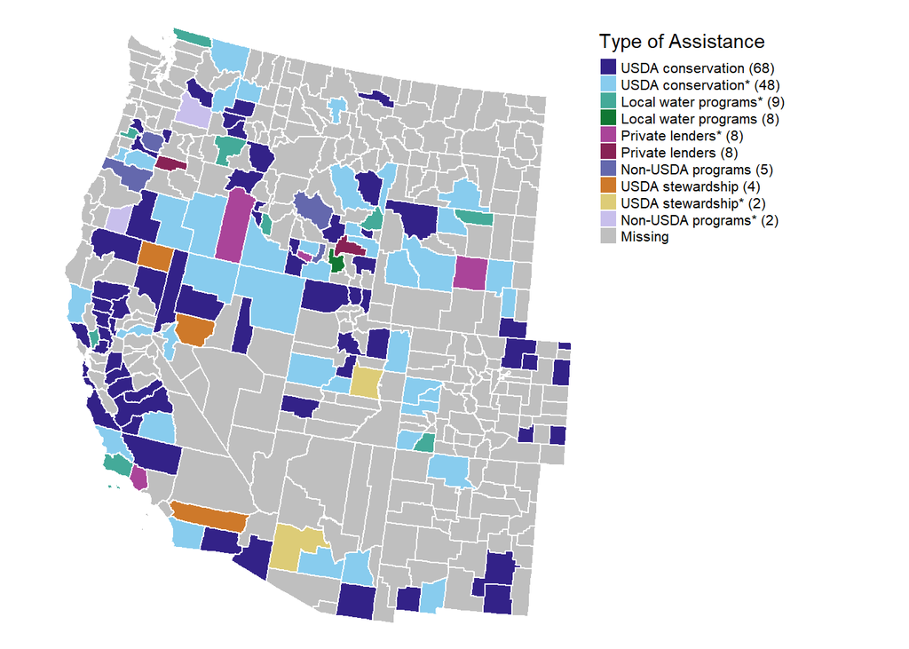

```r
find <- find %>%
  mutate(
    category = case_when(
      category == "K0215 - USDA conservation*" ~ "USDA conservation* (48)",
      category == "K0216 - USDA conservation" ~ "USDA conservation (68)",
      category == "K0217 - USDA stewardship*" ~ "USDA stewardship* (2)",
      category == "K0218 - USDA stewardship" ~ "USDA stewardship (4)",
      category == "K0219 - Non-USDA programs*" ~ "Non-USDA programs* (2)",
      category == "K0235 - Non-USDA programs" ~ "Non-USDA programs (5)",
      category == "K0236 - Local water programs*" ~ "Local water programs* (9)",
      category == "K0237 - Local water programs" ~ "Local water programs (8)",
      category == "K0238 - Private lenders*" ~ "Private lenders* (8)",
      category == "K0239 - Private lenders" ~ "Private lenders (8)"
    )
  )

find$category <- as.factor(find$category)
find$category <- ordered(find$category, levels = c("USDA conservation (68)", "USDA conservation* (48)", "Local water programs* (9)", "Local water programs (8)",  "Private lenders* (8)","Private lenders (8)","Non-USDA programs (5)","USDA stewardship (4)","USDA stewardship* (2)","Non-USDA programs* (2)"))

colnames(find)[4] <- "Type of Assistance"

assist_sp <- sp::merge(w_ctys, find, by = "GEOID", duplicateGeoms = TRUE, all = TRUE)

library(tmap)
assist_map <- tm_shape(w_ctys) + tm_polygons(col="grey", border.col = "white") +
  tm_shape(assist_sp) +
    tm_polygons("Type of Assistance", palette = c("#332288","#88CCEE","#44AA99","#117733","#AA4499","#882255","#6468AD","#CE792A","#DDCC77","#C8BFEC"), border.col = "white")  +
    tm_legend(outside = TRUE) +
    tm_layout(frame= FALSE,
              legend.text.size = 0.65)

assist_map
```

```r
tmap_save(assist_map, "./viz/Manuscript-Figures/Figure9.png", width = 150, height = 150, units = "mm", dpi = 400)
```